# Basic Linear Regression Models

## Coefficient errors

More generally, if our estimators are ‘unbiased’, as in the simulated example, then the standard errors are:

$$SE(\beta_0)^2 = V(\epsilon) \left[\frac{1}{n} + \frac{\bar x^2}{\sum_{i=1}^{n}(x_i-\bar x)^2}\right]$$

and

$$SE(\beta_1)^2 = \frac{V(\epsilon)}{\sum_{i=1}^{n}(x_i-\bar x)^2}$$

Although the residual error $\epsilon$ is unknown, it can be estimated by the *residual standard error* (*RSE*), the square root of the *residual sum of squares* (*RSS*) divided by the degrees of freedom (n-2).

$$RSE = \sqrt{\frac{RSS}{n-2}}$$

With the ‘true’ estimates falling +/- 2*SE in 95% of simulations. That is, in each simulation we can estimate the confidence interval as:

lower 2.5%: $b_1 - 2\times SE(b_1)$

upper 97.5%: $b_1 + 2\times SE(b_1)$

## Association Test

Testing whether $X$ is significantly associated with $Y$ is equivalent to testing whether $b_1$, our estimate of the slope is significantly different from zero, which depends on the standard error of $SE(b_1)$. Under the null hypothesis of no association, the ratio of these parameters follows a $t$-distribution:

$$t = \frac{b_1}{SE(b_1)}$$

### Simulated data

To calculate the SE(b1) and t-statistic to test significance of the model $Y \sim \beta_0 + \beta_1*X$, we first need *RSS*, which requires the model prediction.

First, simulate data again; this time with a smaller sample size:

```r
N<-300
B0<-500
B1<-10
B2<-0
X_c<-rnorm(N)
X_f<-sample(c(0,1),N,replace=T)
Error<-rnorm(N)
Y<-B0 + B1*X_c + B2*X_f + Error
b1<-cov(Y,X_c)/var(X_c)
b0<-mean(Y)-b1*mean(X_c)
paste("Y ~",b0,"+",b1,"* X_c")
```

```
## [1] "Y ~ 499.977035081212 + 10.0524908469173 * X_c"
```

Calculate predicted values for each value of $X_c$

```r
Mpred<-b0+b1*X_c
```

We can use *qplot()* to view how the prediction compares to the observed data:

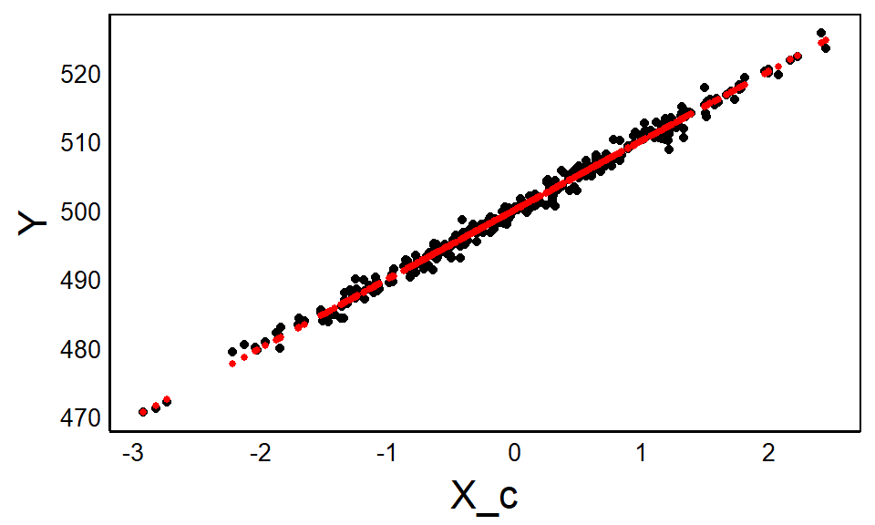

```r
qplot(X_c,Y)+geom_point(aes(x=X_c,y=Mpred),colour="red",size=1)
```

Residuals are just the distance along $Y$ from each point to the predicted value:

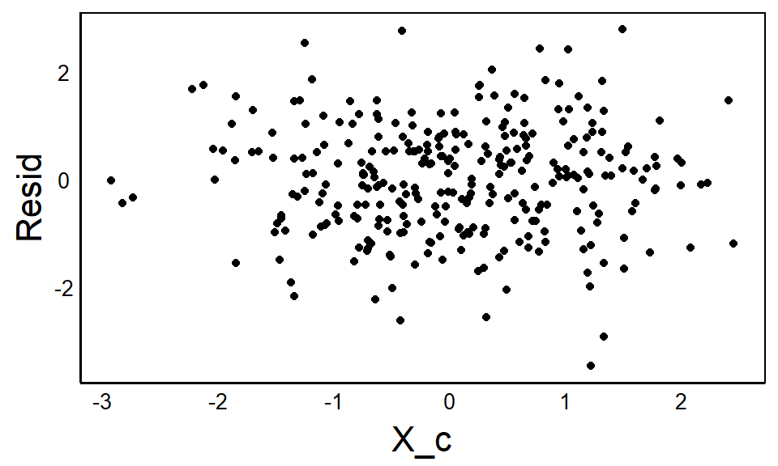

```r
Resid<-Y-Mpred
qplot(X_c,Resid)
```

Residual sum of squares (*RSS*) and root squared error (*RSE*) are:

```r
RSS<-sum(Resid^2)
RSE<-sqrt(RSS/(N-2))
```

which we can use to calculate $SE(b_1)$ and $t$ as:

```r
xdev<-sum((X_c-mean(X_c))^2)
SE.b1<-sqrt(RSE^2/xdev)
t.obs<-b1/SE.b1
```

Finally, we compare our observed t to a null distribution:

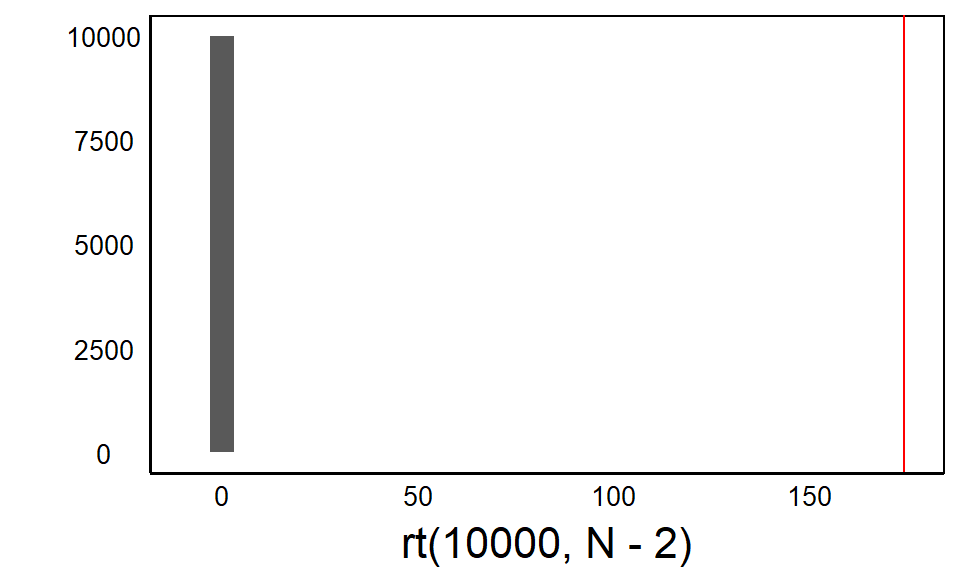

```r
qplot(rt(10000,N-2)) + geom_vline(xintercept=t.obs, colour="red")
```

```r
dt(t.obs,N-2)
```

```
## [1] 6.940243e-302
```

The observed value is so far from the expected that there aren’t enough decimal places in the [float](https://en.wikipedia.org/wiki/Floating-point_arithmetic)to contain the P-value.

## Model Accuracy

*RSE* is a inversely proportional to the model’s accuracy, but is difficult to compare across measurements. A standardized measure of fit is $R_2$ :

$$R^2 = 1-\frac{RSS}{TSS}$$

Where $TSS = \sum (y_i-\bar y)^2$ , the total sum of squares

This turns out to be identical to the squared correlation coefficient $r$:

$$r = COR_{X,Y} = \frac{COV_{x,y}}{\sqrt{V_x*V_y}}$$

### Simulated data:

```r
TSS<-sum((Y-mean(Y))^2)
R2<-1-RSS/TSS
r<-cov(X_c,Y)/sqrt(var(X_c)*var(Y))
R2
```

```
## [1] 0.9902673
```

```r
r^2
```

```
## [1] 0.9902673
```

# Linear models in R

The `lm` function is used to perform ordinary least squares (OLS) models in R.

```r
mod1<-lm(Y~X_c)
str(mod1)
```

```
## List of 12
##  $ coefficients : Named num [1:2] 500 10.1
##   ..- attr(*, "names")= chr [1:2] "(Intercept)" "X_c"
##  $ residuals    : Named num [1:300] -0.215 2.752 -1.301 0.566 1.561 ...
##   ..- attr(*, "names")= chr [1:300] "1" "2" "3" "4" ...
##  $ effects      : Named num [1:300] -8667.937 177.116 -1.109 0.268 1.636 ...
##   ..- attr(*, "names")= chr [1:300] "(Intercept)" "X_c" "" "" ...
##  $ rank         : int 2
##  $ fitted.values: Named num [1:300] 487 496 512 479 504 ...
##   ..- attr(*, "names")= chr [1:300] "1" "2" "3" "4" ...
##  $ assign       : int [1:2] 0 1
##  $ qr           :List of 5
##   ..$ qr   : num [1:300, 1:2] -17.3205 0.0577 0.0577 0.0577 0.0577 ...
##   .. ..- attr(*, "dimnames")=List of 2
##   .. .. ..$ : chr [1:300] "1" "2" "3" "4" ...
##   .. .. ..$ : chr [1:2] "(Intercept)" "X_c"
##   .. ..- attr(*, "assign")= int [1:2] 0 1
##   ..$ qraux: num [1:2] 1.06 1.02
##   ..$ pivot: int [1:2] 1 2
##   ..$ tol  : num 1e-07
##   ..$ rank : int 2
##   ..- attr(*, "class")= chr "qr"
##  $ df.residual  : int 298
##  $ xlevels      : Named list()
##  $ call         : language lm(formula = Y ~ X_c)
##  $ terms        :Classes 'terms', 'formula'  language Y ~ X_c
##   .. ..- attr(*, "variables")= language list(Y, X_c)
##   .. ..- attr(*, "factors")= int [1:2, 1] 0 1
##   .. .. ..- attr(*, "dimnames")=List of 2
##   .. .. .. ..$ : chr [1:2] "Y" "X_c"
##   .. .. .. ..$ : chr "X_c"
##   .. ..- attr(*, "term.labels")= chr "X_c"
##   .. ..- attr(*, "order")= int 1
##   .. ..- attr(*, "intercept")= int 1
##   .. ..- attr(*, "response")= int 1
##   .. ..- attr(*, ".Environment")=<environment: R_GlobalEnv>
##   .. ..- attr(*, "predvars")= language list(Y, X_c)
##   .. ..- attr(*, "dataClasses")= Named chr [1:2] "numeric" "numeric"
##   .. .. ..- attr(*, "names")= chr [1:2] "Y" "X_c"
##  $ model        :'data.frame':   300 obs. of  2 variables:
##   ..$ Y  : num [1:300] 487 499 510 480 505 ...
##   ..$ X_c: num [1:300] -1.248 -0.414 1.155 -2.041 0.385 ...
##   ..- attr(*, "terms")=Classes 'terms', 'formula'  language Y ~ X_c
##   .. .. ..- attr(*, "variables")= language list(Y, X_c)
##   .. .. ..- attr(*, "factors")= int [1:2, 1] 0 1
##   .. .. .. ..- attr(*, "dimnames")=List of 2
##   .. .. .. .. ..$ : chr [1:2] "Y" "X_c"
##   .. .. .. .. ..$ : chr "X_c"
##   .. .. ..- attr(*, "term.labels")= chr "X_c"
##   .. .. ..- attr(*, "order")= int 1
##   .. .. ..- attr(*, "intercept")= int 1
##   .. .. ..- attr(*, "response")= int 1
##   .. .. ..- attr(*, ".Environment")=<environment: R_GlobalEnv>
##   .. .. ..- attr(*, "predvars")= language list(Y, X_c)
##   .. .. ..- attr(*, "dataClasses")= Named chr [1:2] "numeric" "numeric"
##   .. .. .. ..- attr(*, "names")= chr [1:2] "Y" "X_c"
##  - attr(*, "class")= chr "lm"
```

The function returns a list with a number of useful layers. For example, compare the *residuals* slice, which corresponds to a vector of

$$y_i-\bar y$$
The sum of squared values of this vector is the *RSS*

```r
RSS
```

```
## [1] 308.3165
```

```r
sum(mod1$residuals^2)
```

```
## [1] 308.3165
```

The *coefficients* slice gives $b_0$ and $b_1$:

```r
b0
```

```
## [1] 499.977
```

```r
b1
```

```
## [1] 10.05249
```

```r
mod1$coefficients
```

```
## (Intercept)         X_c
##   499.97704    10.05249
```

A summary of the model can be generated using the `summary()` function. This shows coefficients and results of the significance tests.

```r
t.obs
```

```
## [1] 174.1277
```

```r
dt(t.obs,N-2)
```

```
## [1] 6.940243e-302
```

```r
r^2
```

```
## [1] 0.9902673
```

```r
summary(mod1)
```

```
##
## Call:
## lm(formula = Y ~ X_c)
##
## Residuals:
##     Min      1Q  Median      3Q     Max
## -3.4658 -0.7405  0.0676  0.6327  2.7840
##
## Coefficients:
##              Estimate Std. Error t value Pr(>|t|)
## (Intercept) 499.97704    0.05879  8504.9   <2e-16 ***
## X_c          10.05249    0.05773   174.1   <2e-16 ***
## ---
## Signif. codes:  0 '***' 0.001 '**' 0.01 '*' 0.05 '.' 0.1 ' ' 1
##
## Residual standard error: 1.017 on 298 degrees of freedom
## Multiple R-squared:  0.9903, Adjusted R-squared:  0.9902
## F-statistic: 3.032e+04 on 1 and 298 DF,  p-value: < 2.2e-16
```

We can also generate predicted values from the model using the `predict()` function:

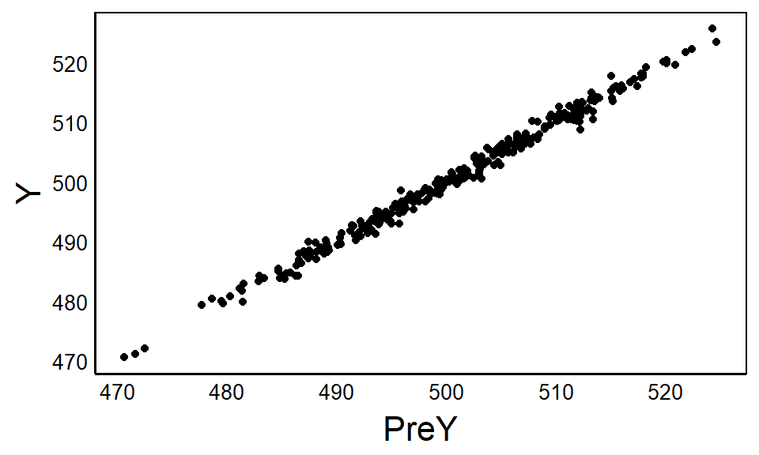

```r
PreY<-predict(mod1)
qplot(PreY,Y)
```

# Multiple regression

```r
B2<-5
B3<--2
Y<-B0 + B1*X_c + B2*X_f + B3*X_c*X_f+ Error
```

Inspect the data:

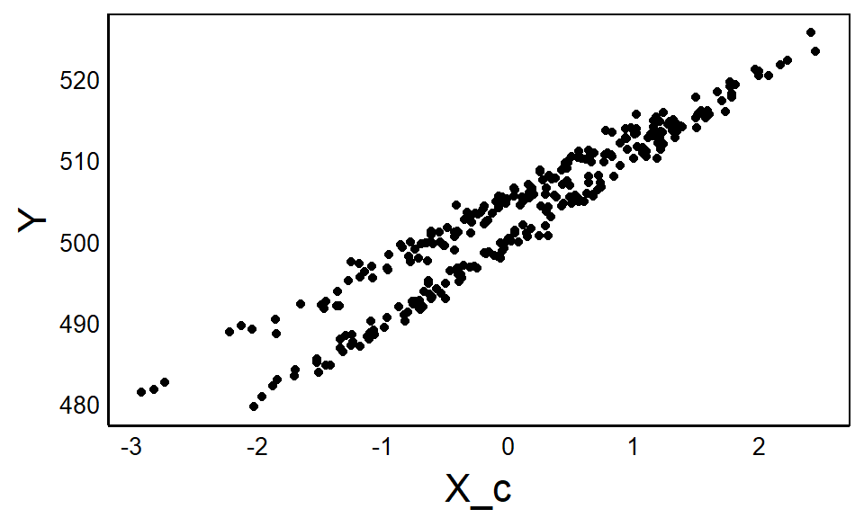

```r
qplot(X_c,Y)
```

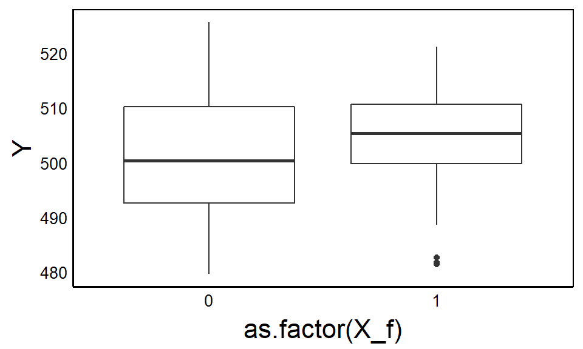

```r
qplot(as.factor(X_f),Y,geom="boxplot")
```

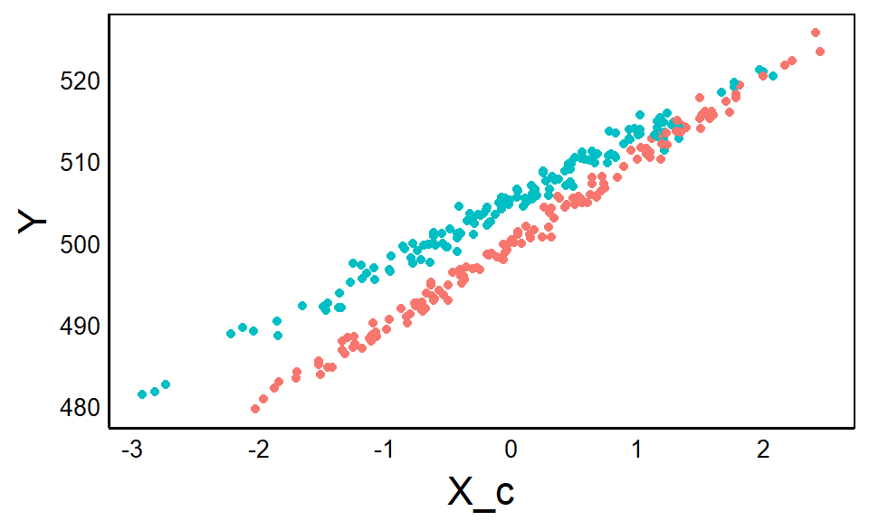

```r
qplot(X_c,Y,colour=as.factor(X_f))
```

Estimating the coefficients in a multiple regression is more complicated than the single-variable model. However, it is still easy to analyze models in R using the `lm` function. We can also use this to demonstrate the influence of *lurking* or *confounding* variables. These are factors that affect $Y$ but are not in our model. For example, let’s try the same single-variable linear model:

```r
mod2<-lm(Y ~ X_c)
summary(mod2)
```

```
##
## Call:
## lm(formula = Y ~ X_c)
##
## Residuals:
##     Min      1Q  Median      3Q     Max
## -5.2093 -2.5904  0.1129  2.4325  6.1235
##
## Coefficients:
##             Estimate Std. Error t value Pr(>|t|)
## (Intercept) 502.5838     0.1649 3047.91   <2e-16 ***
## X_c           8.9745     0.1619   55.42   <2e-16 ***
## ---
## Signif. codes:  0 '***' 0.001 '**' 0.01 '*' 0.05 '.' 0.1 ' ' 1
##
## Residual standard error: 2.853 on 298 degrees of freedom
## Multiple R-squared:  0.9116, Adjusted R-squared:  0.9113
## F-statistic:  3072 on 1 and 298 DF,  p-value: < 2.2e-16
```

Compare the estimates and standard errors for $X_c$ from `mod2` with the true coefficients (are they within 2x SE?):

```r
B<-summary(mod2)$coefficients[,1]
SE<-summary(mod2)$coefficients[,2]
B-2*SE
```

```
## (Intercept)         X_c
##  502.254014    8.650617
```

```r
B+2*SE
```

```
## (Intercept)         X_c
##  502.913591    9.298341
```

```r
c(B0,B1)
```

```
## [1] 500  10
```

Now contrast to the previous simulated data for mod1, in which $\beta_2 = 0$:

```r
mod1$coefficients
```

```
## (Intercept)         X_c
##   499.97704    10.05249
```

## ‘Biased’ estimate

This is a good example of ‘biased’ estimates. By excluding the effect of other variables that affect $Y$, we bias our estimates of $\beta_0$ and $\beta_1$.

Now let’s try including the missing variable:

```r
mod3<-lm(Y ~ X_c + X_f)
summary(mod3)$coefficients[,1:2]
```

```
##               Estimate Std. Error
## (Intercept) 500.100264 0.12337883
## X_c           9.101416 0.08481409
## X_f           4.858132 0.17258724
```

```r
c(B0,B1)
```

```
## [1] 500  10
```

Now the intercept is within 2x SD, but the $b_1$ is still biased. The reason is that we are also missing an interaction term in the model – i.e. $b_1$ is different for the two groups in $X_f$.

We use the colon `:` to specify interaction terms in the `lm` function:

```r
mod4<-lm(Y ~ X_c + X_f + X_c:X_f)
```

There is also a short-form using `*` to indicate ’all additive and interaction terms:

```r
mod4<-lm(Y ~ X_c*X_f)
summary(mod4)$coefficients[,1:2]
```

```
##               Estimate Std. Error
## (Intercept) 499.996838 0.08432096
## X_c          10.119506 0.07981183
## X_f           4.954121 0.11780649
## X_c:X_f      -2.144008 0.11582102
```

```r
c(B0,B1,B2,B3)
```

```
## [1] 500  10   5  -2
```

Comparing the simulated with observed coefficients, the model looks unbiased now that we have included all of the factors in the model.

## Model Fit

The `summary()` function provides a $t$-test for each coefficient in the model, but what if we want to compare whether two models are significantly different? For example, what if I want to test if the full model is significantly better than one that only includes $X_c$?:

```r
TestMod1<-lm(Y ~ X_c)
TestMod2<-lm(Y ~ X_c*X_f)
```

**NOTE**: The **hierarchical principal** states that if a model contains an interaction term, it should also include the individual effects that make up the interaction. That’s way we remove $X_c:X_f$ when we remove $X_f$ in TestMod1 in the above code.

We could compare the fit of the two models to the data, using $R^2$ values, where $R^2$ is the squared correlation between predicted and observed $Y$:

$$R^2 = [COR(y , \hat y)]^2$$

Let’s test this:

```r
b<-TestMod1$coefficients
Y_hat<-b[1]+b[2]*X_c
cor(Y,Y_hat)^2
```

```
## [1] 0.9115609
```

```r
summary(TestMod1)$r.squared
```

```
## [1] 0.9115609
```

Comparing the $R^2$ of the two models:

```r
summary(TestMod1)$r.squared
```

```
## [1] 0.9115609
```

```r
summary(TestMod2)$r.squared
```

```
## [1] 0.9888251
```

This looks good, but one problem with the equation is that $R^2$ will improve just by adding random variables:

```r
TestMod3<-lm(Y ~ X_c*X_f+rnorm(N)+rnorm(N)+rnorm(N)+rnorm(N))
summary(TestMod3)$r.squared
```

```
## [1] 0.9889132
```

### $R^{2}_{adj}$

One solution is to adjust or *weight* the estimate of the model fit by the number of parameters included in the model.

For example, the root squared error (RSE) adjusts the RSS based on both the number of observations and the number of model coefficients:

$$RSE = \sqrt{\frac{RSS}{n-p-1}}$$

In an analogous fashion, $R^2_{adj}$ adjusts $R^2$ based on the number of parameters in the model:

```r
R2<-summary(TestMod1)$r.squared
(Radj<-(1-R2)*(N-1)/(N-1-1))
```

```
## [1] 0.08873587
```

```r
summary(TestMod1)$adj.r.squared
```

```
## [1] 0.9112641
```

```r
summary(TestMod1)$r.squared
```

```
## [1] 0.9115609
```

```r
summary(TestMod2)$r.squared
```

```
## [1] 0.9888251
```

### $F$-test

We can also test statistically whether one model performs better than the other using an F-test:

$$F = \frac{(RSS_1-RSS_2)/q}{RSS_2/(n-p-1)}$$

Where $q$ is the number of parameters differing between the full model (model 2) and the model with $q$ parameters removed (model 1); $RSS_2$ and $RSS_1$ are the residual sums of the respective models.

The `anova()` function can be used to implement this test on an `lm()` object:

```r
anova(TestMod1,TestMod2)
```

```
## Analysis of Variance Table
##
## Model 1: Y ~ X_c
## Model 2: Y ~ X_c * X_f
##   Res.Df     RSS Df Sum of Sq      F    Pr(>F)
## 1    298 2425.75
## 2    296  306.51  2    2119.2 1023.3 < 2.2e-16 ***
## ---
## Signif. codes:  0 '***' 0.001 '**' 0.01 '*' 0.05 '.' 0.1 ' ' 1
```

# Factors

In our simulated dataset, we encoded a categorical variable (i.e. factor) $X_f$ as 0 or 1. A nice feature of the `lm()` function is that it automatically encodes categorical variables in this way. To demonstrate, let’s create a new factor variable $X_fac$ that contains categories “A” and “B”:

```r
X_fac<-{}
X_fac[X_f==0]<-"A"
X_fac[X_f==1]<-"B"
str(X_fac)
```

```
##  chr [1:300] "A" "B" "B" "B" "A" "B" "A" "B" "B" "B" "B" "B" "B" "B" ...
```

And compare models with the two encodings:

```r
OldMod<-lm(Y ~ X_c*X_f)
NewMod1<-lm(Y ~ X_c*X_fac)
summary(OldMod)$coefficients
```

```
##               Estimate Std. Error    t value      Pr(>|t|)
## (Intercept) 499.996838 0.08432096 5929.68642  0.000000e+00
## X_c          10.119506 0.07981183  126.79207 5.408572e-260
## X_f           4.954121 0.11780649   42.05304 7.230370e-127
## X_c:X_f      -2.144008 0.11582102  -18.51139  2.344033e-51
```

```r
summary(NewMod1)$coefficients
```

```
##               Estimate Std. Error    t value      Pr(>|t|)
## (Intercept) 499.996838 0.08432096 5929.68642  0.000000e+00
## X_c          10.119506 0.07981183  126.79207 5.408572e-260
## X_facB        4.954121 0.11780649   42.05304 7.230370e-127
## X_c:X_facB   -2.144008 0.11582102  -18.51139  2.344033e-51
```

Our $X_f$ is an example of a *dummy variable*, which is just a mathematical encoding of a non-mathematical categorical variable.

## Intercepts: 1 & 0

Note that if we want to predicted means $\bar y$ for the two groups ($A$ and $B$), we would use the coefficients:

$$\bar y_A = b_0 (+ b_2 \times 0)$$
$$= b_0$$

$$\bar y_B = b_0 (+ b_2 \times 1)$$
$$= b_0 + b_2$$

In this case, the *intercept* $b_0$ is the mean for the first level of $X_f$. Adding $b_2$ (the ‘Estimate’ for X_f) to the intercept yields the mean for group ‘B’.

## Alternative: -1 & 1

An alternative coding for $X_f$ is $-1$ and $+1$. Let’s make re-encode $X_f$ this way and compare the coefficients:

```r
X_f2<-X_f
X_f2[X_f2==0]<--1
AltMod<-lm(Y ~ X_c*X_f2)
summary(AltMod)$coefficients[,1:2]
```

```
##               Estimate Std. Error
## (Intercept) 502.473899 0.05890325
## X_c           9.047502 0.05791051
## X_f2          2.477061 0.05890325
## X_c:X_f2     -1.072004 0.05791051
```

```r
summary(OldMod)$coefficients[,1:2]
```

```
##               Estimate Std. Error
## (Intercept) 499.996838 0.08432096
## X_c          10.119506 0.07981183
## X_f           4.954121 0.11780649
## X_c:X_f      -2.144008 0.11582102
```

Note how the coefficients have changed; not just for X_f2 but also for the intercept, X_c and the interaction coefficients.

Now the equations are:

$$\bar y_A = b_0 (+ b_2 \times -1)$$

$$= b_0 - b_2$$

and

$$\bar y_B = b_0 (+ b_2 \times 1)$$
$$= b_0 + b_2$$

## Beyond binary

We have seen different encodings for a factor with just two levels, but what if there are three or more groups?

In general, a factor with n levels can be encoded by n-1 dummy variables. For example, if we have 3 groups “A”, “B”, and “C”, we can encode dummy variables for “B” and “C” using 1 vs 0:

| Category | dummyB (b1) | dummyC (b2) |
| --- | --- | --- |
| A | 0 | 0 |
| B | 1 | 0 |
| C | 0 | 1 |

So our estimates for group means are:

$$\bar y_A = b_0 + b_1 \times 0 + b_2 \times 0$$

$$= b_0$$

$$\bar y_B = b_0 + b_1 \times 1 + b_2 \times 0$$

$$= b_0 + b_1$$

$$\bar y_A = b_0 + b_1 \times 0 + b_2 \times 1$$

$$= b_0 + b_2$$

We could add a fourth variable “D” to our factor, and here again there are different possible codings.

First, we could add another dummy variable:

| Category | dummyB (b1) | dummyC (b2) | dummyD (b3) |
| --- | --- | --- | --- |
| A | 0 | 0 | 0 |
| B | 1 | 0 | 0 |
| C | 0 | 1 | 0 |
| D | 0 | 0 | 1 |

And indeed, this is how `lm()` would encode it.

> What is an alternative way to code for “D” without adding a column?

> What would the equation for $\hat y_D$ look like for these two ways of encoding?

We can see this encoded in the `lm` output. For example:

```r
Yr<-rnorm(100)
Xr<-sample(c("A","B","C"),100,replace=T)
ModRand<-lm(Yr ~ Xr)
summary(ModRand)$coefficients[,1:2]
```

```
##                 Estimate Std. Error
## (Intercept)  0.128394115  0.1588044
## XrB          0.007960332  0.2178779
## XrC         -0.137424284  0.2150222
```

# Nonlinear regression

We have already looked at the effect of an interaction term on our simulated data. This is an example of a non-linear relationship because the effect of $X_c$ on $Y$ is **dependent** on the value of $X_f$.

Another form of nonlineartity is when the relationship between two variables do not form a straight line. For example:

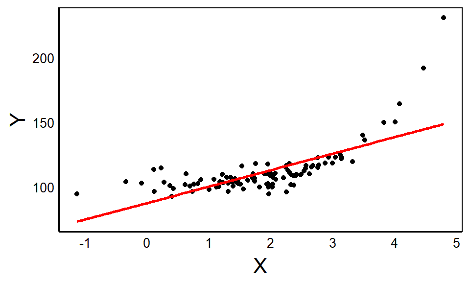

```r
X<-rnorm(100)+2
Y<-exp(X)+rnorm(100,sd=5)+100
qplot(X,Y)+
  geom_smooth(method="lm",colour="red",se=F)
```

### Quadratic

A simple way to test for a nonlinear relationship between two variables is to add a square of the predictor variable:

```r
summary(lm(Y ~ X + I(X^2)))
```

```
##
## Call:
## lm(formula = Y ~ X + I(X^2))
##
## Residuals:
##     Min      1Q  Median      3Q     Max
## -30.167  -4.381   0.392   3.631  36.369
##
## Coefficients:
##             Estimate Std. Error t value Pr(>|t|)
## (Intercept) 103.9583     2.0325  51.148  < 2e-16 ***
## X           -11.3305     1.9355  -5.854 6.53e-08 ***
## I(X^2)        6.3114     0.4667  13.524  < 2e-16 ***
## ---
## Signif. codes:  0 '***' 0.001 '**' 0.01 '*' 0.05 '.' 0.1 ' ' 1
##
## Residual standard error: 7.832 on 97 degrees of freedom
## Multiple R-squared:  0.8269, Adjusted R-squared:  0.8234
## F-statistic: 231.7 on 2 and 97 DF,  p-value: < 2.2e-16
```

**NOTE**: the use of the identity function `I()` for the squared term. This is necessary for `lm()` to recognize the parameter. You can remove the `I()` function and re-run the command for comparison.

> How can we test if the non-linear model fits the data better than the linear model?

We can use the $F$-test:

```r
LMod<-lm(Y ~ X)
nLMod<-lm(Y ~ X + I(X^2))
anova(LMod,nLMod)
```

```
## Analysis of Variance Table
##
## Model 1: Y ~ X
## Model 2: Y ~ X + I(X^2)
##   Res.Df     RSS Df Sum of Sq      F    Pr(>F)
## 1     98 17168.9
## 2     97  5949.8  1     11219 182.91 < 2.2e-16 ***
## ---
## Signif. codes:  0 '***' 0.001 '**' 0.01 '*' 0.05 '.' 0.1 ' ' 1
```

The result is highly significant, indicating a much better fit to the data. This is evident if we plot the linear and quadratic models:

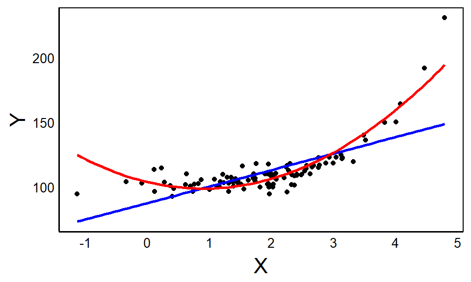

```r
qplot(X,Y)+
  geom_smooth(method="lm",
              formula = y ~ x, colour="blue",se=F)+
  geom_smooth(method="lm",
              formula = y ~ x + I(x^2),colour="red",se=F)
```

Note that the quadratic model fits pretty well, but that doesn’t mean that the ‘true’ relationship is quadratic. In fact, it’s exponential in our simulation.

We can add high-order polynomials as well:

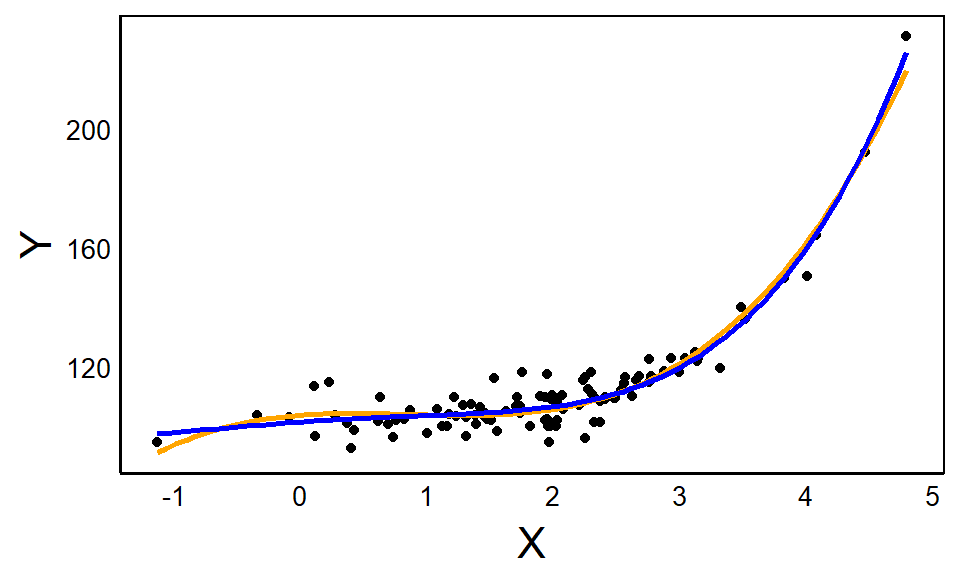

```r
qplot(X,Y)+
  geom_smooth(method="lm",
              formula = y ~ x + I(x^2)
              + I(x^3),colour="orange",se=F) +
  geom_smooth(method="lm",
              formula = y ~ x + I(x^2)
              + I(x^3) + I(x^4),colour="blue",se=F)
```

> Write a script to conduct an $F$-test to see if adding the 3-rd order (x^3) and/or 4th-order (x^4) terms are significantly better than the simpler 2nd-order model.

We could try other transformations of the predictor variable:

### Square root

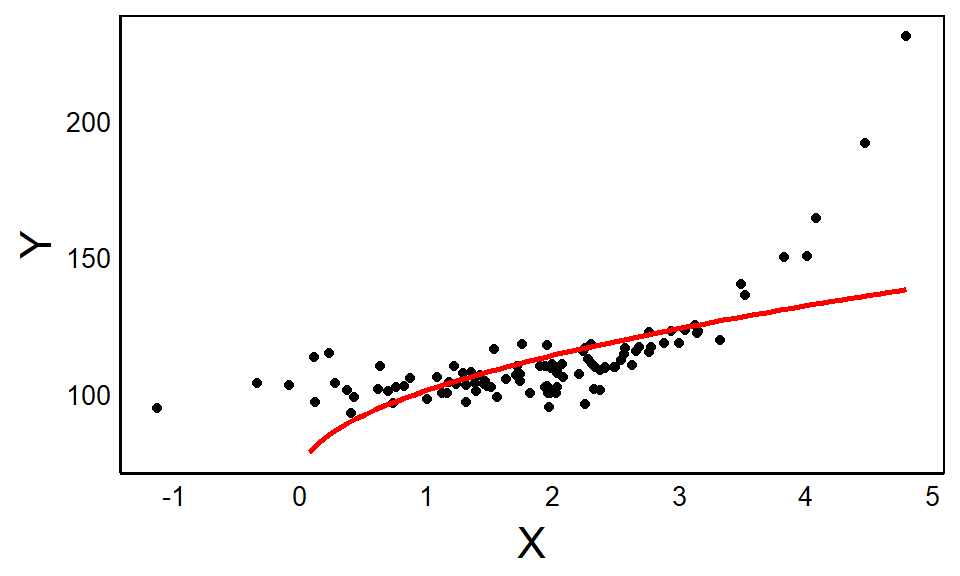

```r
qplot(X,Y)+
  geom_smooth(method="lm",
              formula = y ~ sqrt(x),colour="red",se=F)
```

### Exponential

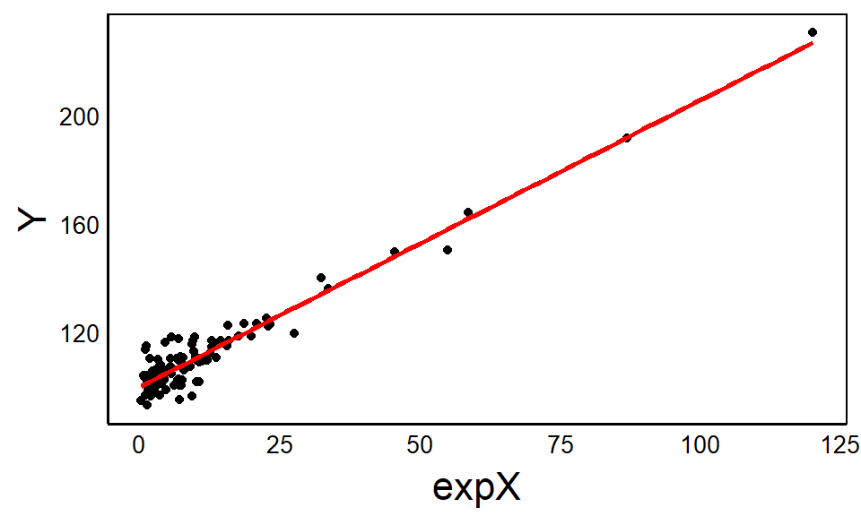

```r
expX<-exp(X)
qplot(expX,Y)+
  geom_smooth(method="lm",
              formula = y ~ x,colour="red",se=F)
```

### Transform Y

Just as we can transform the predictors, we can transform the response variable. The most common is the log-transformation, which is often useful for data involving counts and unbounded percentages (Poisson distribution) and when the predictor variables are multiplicative rather than additive. This is because:

$$log(X_1 X_2 X_3) = log(X_1) + log(X_2) + log(X_3)$$

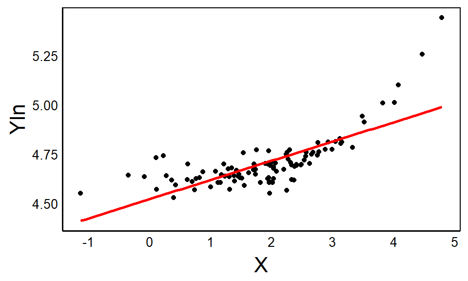

```r
Yln<-log(Y)
qplot(X,Yln)+
  geom_smooth(method="lm",
              formula = y ~ x,colour="red",se=F)
```

# Biased errors

Correlated errors are common in biological studies. Individuals from the same group may have different error variances, for example different treatments, populations or families.

Space and time also cause correlated errors since two samples from adjacent locations or similar time points are more likely to be similar than two randomly chosen samples. Treating these data as independent data points using a simple `lm()` model is a form of *pseudoreplication*.

What happens if errors are not independent? Once again, let’s try a simulation:

```r
corY<-B0 + B1*X_c + B2*X_f + rnorm(100) +
  rnorm(100,sd=10)*X_f
```

This is an example of *heterskedasticity*, or unequal variances among groups:

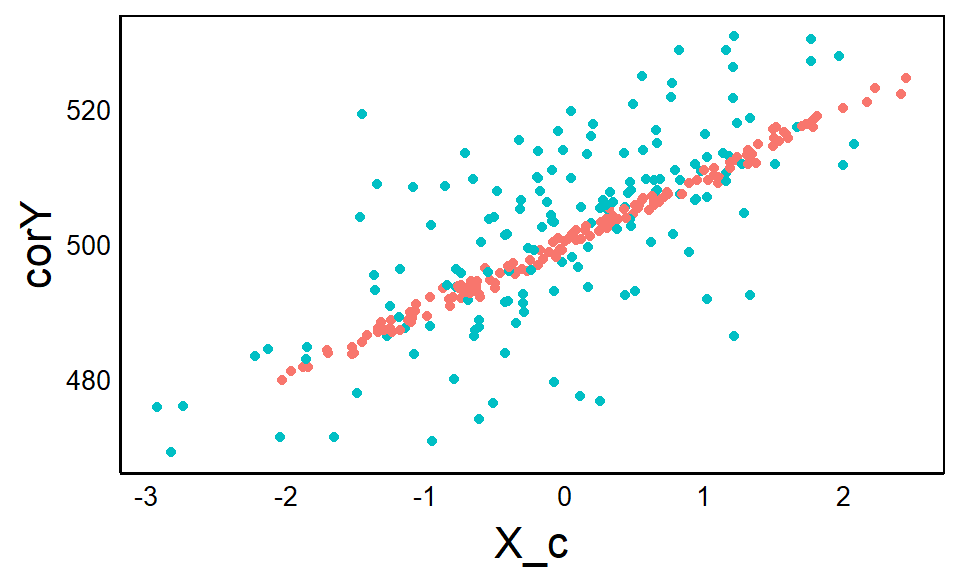

```r
qplot(X_c,corY,colour=as.factor(X_f))
```

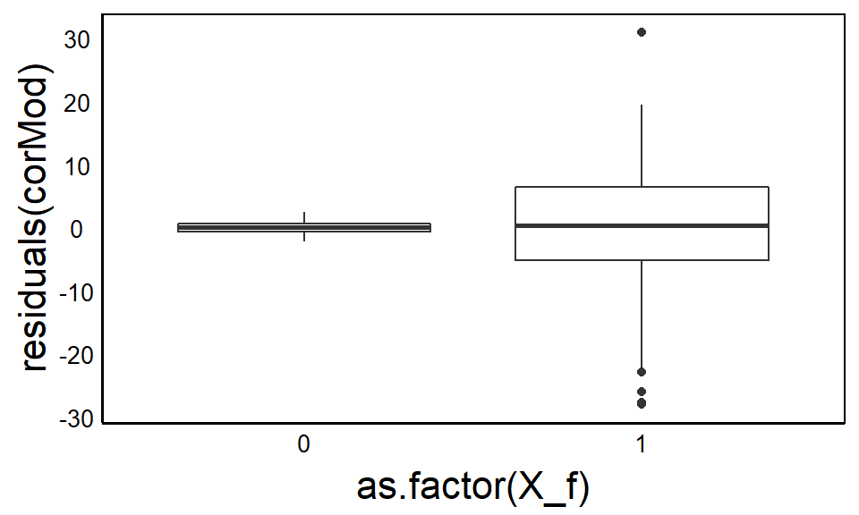

```r
corMod<-lm(corY ~ X_c + X_f)
qplot(as.factor(X_f),residuals(corMod), geom="boxplot")
```

Another common source of heteroskedasticity is the scaling of the variance with the mean, with the points spread out at higher levels of $X$:

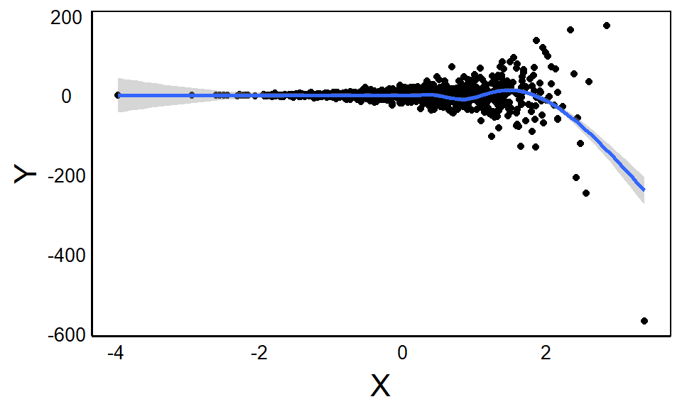

```r
X<-rnorm(1000)
Y<-2*exp(X)*rnorm(1000,sd=5)
qplot(X,Y)+geom_smooth()
```

In this case, transforming the response variable with a log function reduces the large variables more than the small ones, resulting lis less variability:

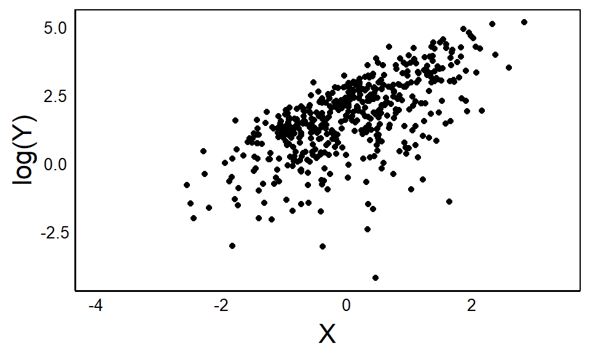

```r
qplot(X,log(Y))
```

# Outliers

Outliers can have a large effect on our estimates, for example, compare these models:

```r
X<-rnorm(100)
Y<-X+rnorm(100)
summary(lm(Y ~ X))
```

```
##
## Call:
## lm(formula = Y ~ X)
##
## Residuals:
##     Min      1Q  Median      3Q     Max
## -1.8348 -0.5987 -0.1014  0.7856  2.4452
##
## Coefficients:
##             Estimate Std. Error t value Pr(>|t|)
## (Intercept) -0.08712    0.09642  -0.903    0.368
## X            1.07592    0.10023  10.735   <2e-16 ***
## ---
## Signif. codes:  0 '***' 0.001 '**' 0.01 '*' 0.05 '.' 0.1 ' ' 1
##
## Residual standard error: 0.9642 on 98 degrees of freedom
## Multiple R-squared:  0.5404, Adjusted R-squared:  0.5357
## F-statistic: 115.2 on 1 and 98 DF,  p-value: < 2.2e-16
```

```r
Yout<-Y
Yout[X==max(X)]<- 100
X[Yout==100]<- 10
summary(lm(Yout ~ X))
```

```
##
## Call:
## lm(formula = Yout ~ X)
##
## Residuals:
##     Min      1Q  Median      3Q     Max
## -10.141  -3.788  -0.627   3.276  41.424
##
## Coefficients:
##             Estimate Std. Error t value Pr(>|t|)
## (Intercept)   0.4480     0.6226    0.72    0.473
## X             5.8128     0.4541   12.80   <2e-16 ***
## ---
## Signif. codes:  0 '***' 0.001 '**' 0.01 '*' 0.05 '.' 0.1 ' ' 1
##
## Residual standard error: 6.216 on 98 degrees of freedom
## Multiple R-squared:  0.6257, Adjusted R-squared:  0.6219
## F-statistic: 163.8 on 1 and 98 DF,  p-value: < 2.2e-16
```

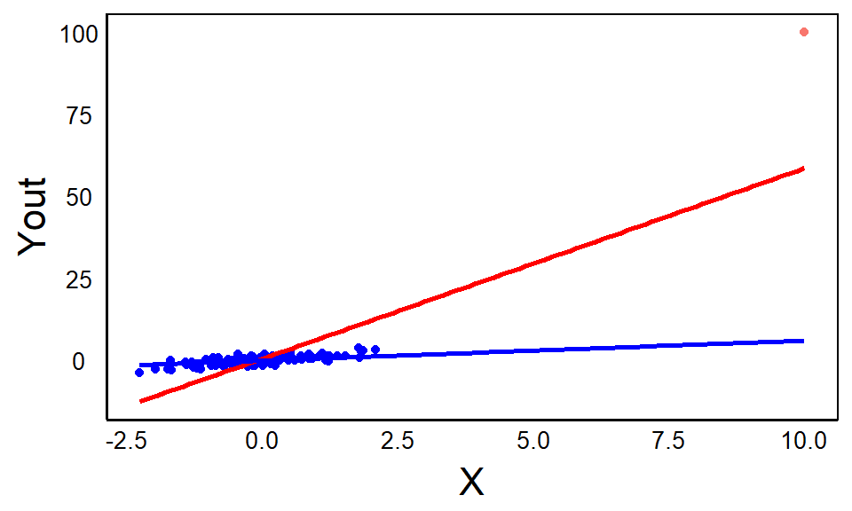

```r
qplot(X,Yout,colour=I("blue"))+
  geom_point(aes(max(X),max(Yout),colour="red"))+
  geom_smooth(method="lm",se=F,colour="red")+
  geom_smooth(aes(X,Y),method="lm",se=F,colour="blue")
```

Outliers can be hard to detect when there are many variables. In these cases we can use a *leverage statistic* to identify points with unusually high influence. One option for this is the `hat()` function in R:

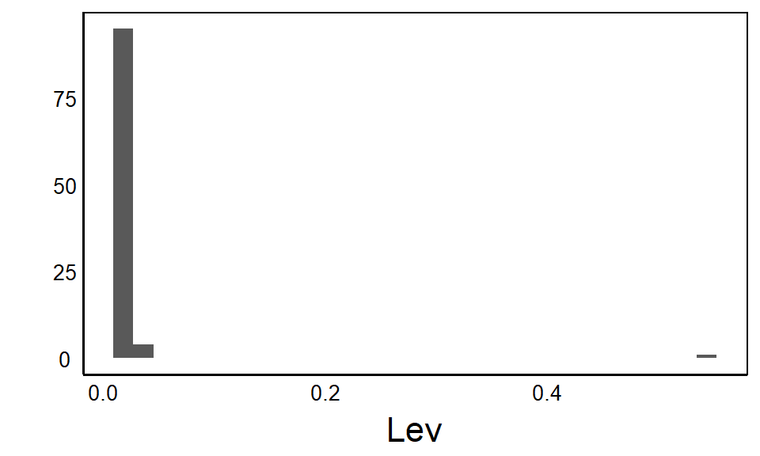

```r
outMod<-lm(Yout ~ X)
M<-model.matrix(outMod)
Lev<-hat(M)
qplot(Lev)
```

```r
Yout[Lev > 0.2] # value of Yout with high leverage
```

```
## [1] 100
```

# Colinearity

Collinearity occurs when two or more predictors are highly correlated.

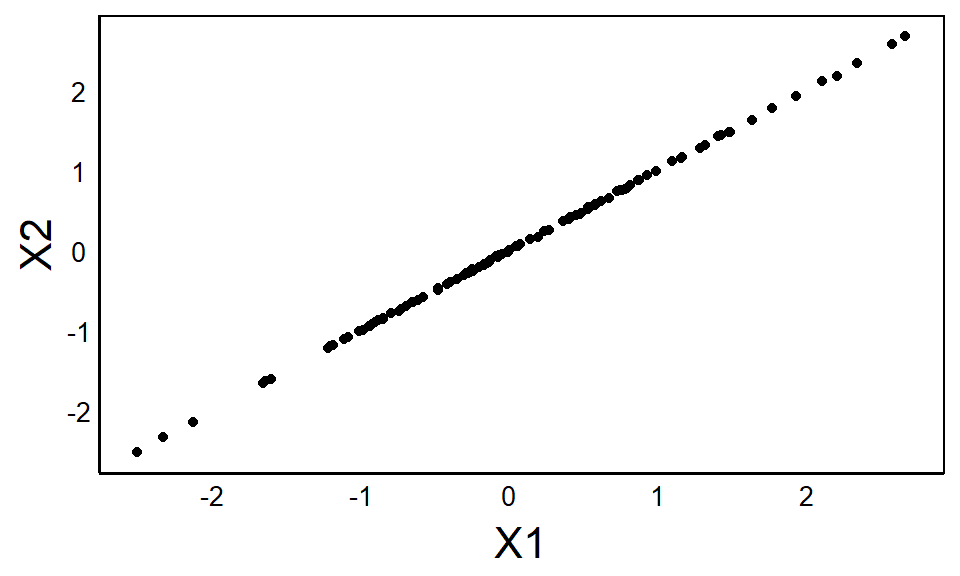

```r
X1<-rnorm(100)
X2<-X1+rnorm(100,sd=0.01)
Y<-100+2*X1+rnorm(100)
qplot(X1,X2)
```

```r
summary(lm(Y ~ X1 + X2))
```

```
##
## Call:
## lm(formula = Y ~ X1 + X2)
##
## Residuals:
##     Min      1Q  Median      3Q     Max
## -2.3545 -0.4923  0.1413  0.5848  2.4664
##
## Coefficients:
##             Estimate Std. Error  t value Pr(>|t|)
## (Intercept) 99.92753    0.09091 1099.202   <2e-16 ***
## X1           1.81177    9.29456    0.195    0.846
## X2           0.19259    9.28687    0.021    0.983
## ---
## Signif. codes:  0 '***' 0.001 '**' 0.01 '*' 0.05 '.' 0.1 ' ' 1
##
## Residual standard error: 0.907 on 97 degrees of freedom
## Multiple R-squared:  0.8463, Adjusted R-squared:  0.8432
## F-statistic: 267.1 on 2 and 97 DF,  p-value: < 2.2e-16
```

Notice that $X_2$ does not affect $Y$ in the simulated data, but $X_1$ does. However, neither is significant in the model, and estimates are far from the actual values. Re-run the above script several times and compare the coefficients.

The reason is that there are many parameter values of the collinear variables that give very simlar estimates of Y.

Visual inspection of bivariate plots, or a correlation matrix, of all your variables, can help to identify collinear data. However, collinearity may exist among more than 2 variables in combination, this is called *multicollinearity*. For example:

```r
CorDat<-data.frame(X1=rnorm(100),X2=rnorm(100),X3=rnorm(100))
CorDat$X4<-CorDat$X1+CorDat$X2+CorDat$X3
cor(x=CorDat)
```

```
##             X1          X2         X3        X4
## X1  1.00000000 -0.03406241 -0.1140984 0.4598449
## X2 -0.03406241  1.00000000 -0.1193990 0.5583680
## X3 -0.11409839 -0.11939895  1.0000000 0.5442865
## X4  0.45984491  0.55836796  0.5442865 1.0000000
```

In this example, $X4$ is a linear combination of $X1$ through $X3$, and yet the pairwise correlations are week. The variance inflation factor **VIF** can be applied to a linear model object to test for multicollinearity using the `vif()` function in the `car` package in R.

# KNN regression

$K$-nearest neighbours regression is a nonparametric method, making it more robust to violations of the assumptions of parametric model (e.g. unbiased estimators, normally distributed error, etc.)

The approach examines $K$ points closest to a particular data point $x_0$ and then estimates a function for that set of points:

$$\hat f(x_0) = \frac{1}{K}\sum_{x_i \in N_0}y_i$$

where $N_0$ is the set of training observations.

When $K = 1$ every point is fit, whereas the function becomes smoother as $K$ increases. The optimal $K$ requires finding the optimum between minimizing the **bias** of the model due to poorly fit data points (low $K$) while minimizing the **variance** – i.e. maximizing the likelihood that the model will work well on an independent dataset. This is the *bias-variance* trade-off.

Linear regression will generally out-perform KNN if the linear function is close to the ‘true’ function, and as the ratio of observations ($n$) to predictors ($p$) decreases. However, KNN can be useful for large datasets with complex relationships between predictor and response variables.

KNN can be implemented in R using the `knn.reg()` function from the `FNN` library.

```r
library(FNN)
```

### $K = 10$

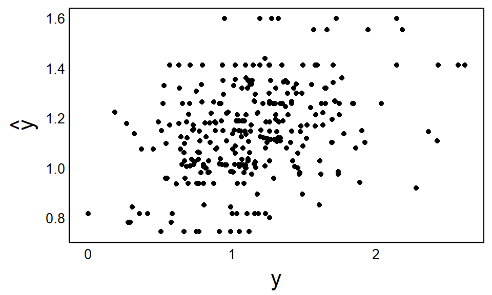

```r
trait.knn<-knn.reg(TraitDat$LatSD, y=TraitDat$PC1SD, k=10)
qplot(TraitDat$PC1SD, trait.knn$pred)+
      xlab("y") + ylab(expression(hat(y)))
```

### $K = 1$

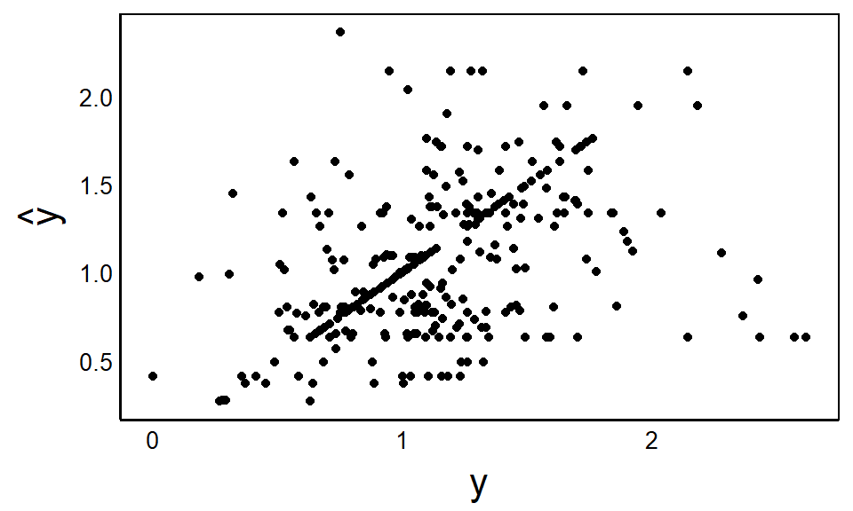

```r
trait.knn<-knn.reg(TraitDat$LatSD, y=TraitDat$PC1SD, k=1)
qplot(TraitDat$PC1SD, trait.knn$pred)+
      xlab("y") + ylab(expression(hat(y)))
```

# Assignment: